#### Students : Hicham Tazi \& Ibrahim Resmouki

#### Ecole Centrale de Casablanca

#### March 2021

# Introduction

This dataset consists of 'circles' (or 'friends lists') from Facebook. Facebook data was collected from survey participants using this Facebook app. The dataset includes node features (profiles), circles, and ego networks.

Facebook data has been anonymized by replacing the Facebook-internal ids for each user with a new value. Also, while feature vectors from this dataset have been provided, the interpretation of those features has been obscured. For instance, where the original dataset may have contained a feature "political=Democratic Party", the new data would simply contain "political=anonymized feature 1". Thus, using the anonymized data it is possible to determine whether two users have the same political affiliations, but not what their individual political affiliations represent.

Link : https://snap.stanford.edu/data/ego-Facebook.html

### Objectives of this project :

- *Formatting Data for Social Network Analysis* : The Data is already formatted and clean, but huge. We then lost a little bit the visual power of the graphs and the methods used were CPU/GPU consuming, so the notebook takes time to execute all the cells.
- *Social Network Analysis with networkx (micro, macro level metrics)* : We used several methods to analyse our Network. Indeed we opted in the this project for **descriptive analysis rather than the predictive one**. We performed ; Betweenness Centrality, Degree Centrality, Closeness Centrality, Shortest path algorithm and Eigenvector Centrality
- *Network visualization*

```python
import networkx as nx
import matplotlib.pyplot as plt
from collections import Counter
```

[output not shown]

```python
G1 =nx.read_edgelist("facebook_combined.txt", create_using = nx.Graph(), nodetype=int)
print(nx.info(G1))
```

```
Name:
Type: Graph
Number of nodes: 4039
Number of edges: 88234
Average degree:  43.6910
```

# I. Betweenness Centrality

Betweenness Centrality is a measure of the centrality of a vertex of a graph. It is equal to the number of times this vertex is on the shortest path between any two other nodes of the graph. A node possesses high intermediality if it has a great influence on the data transfers in the network, under the assumption that these transfers take place only on the shortest paths.  
Given a vertex $v$ of the graph, the betweenness centrality is calculated with this mathematical relation : $g(v) = \sum_{s \neq v \neq t} \frac{\sigma_{st}(v)}{\sigma_{st}}$, where :  
$\sigma_{st}$ : the number of shortest paths between $s$ and $t$  
$\sigma_{st}(v)$ : the number of shortest paths between $s$ and $t$ containing $v$

```
[107, 1684, 3437, 1912, 1085]
```

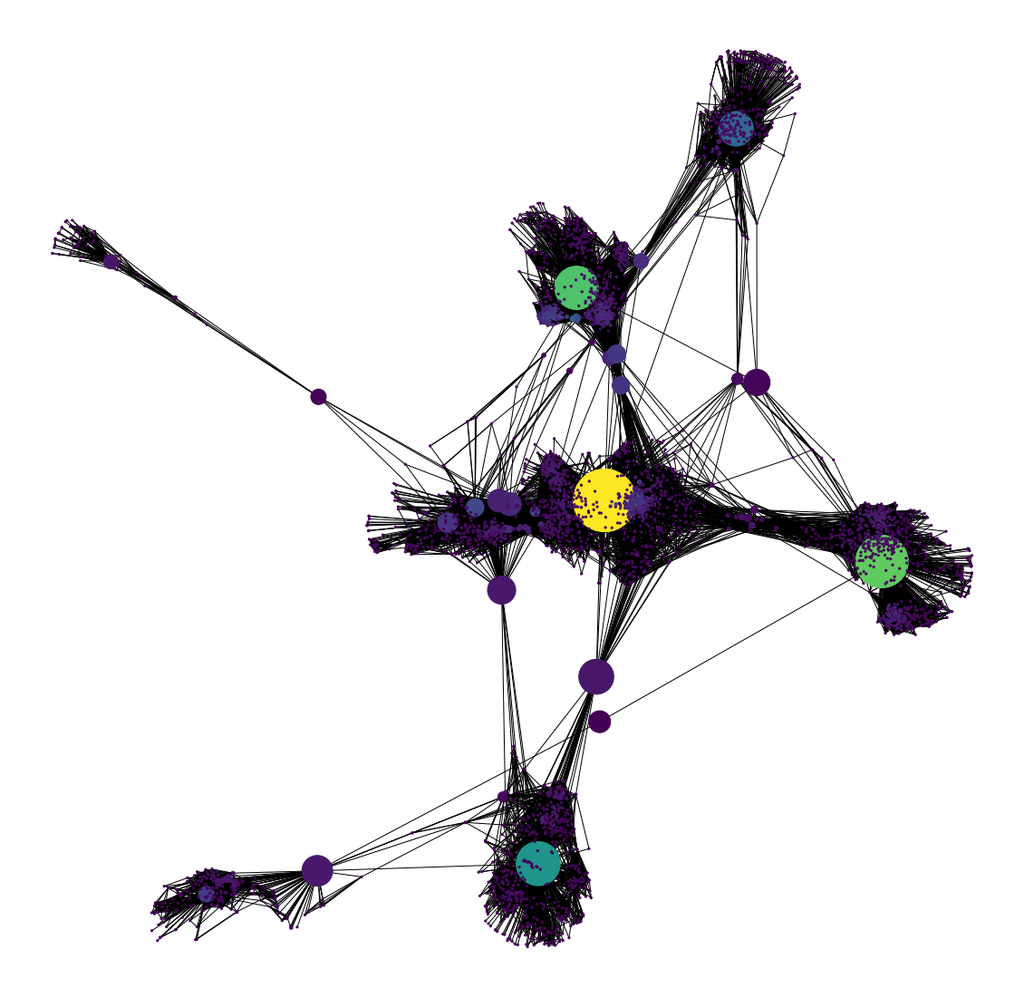

```python
pos = nx.spring_layout(G1)
betCent = nx.betweenness_centrality(G1, normalized=True, endpoints=True)
node_color = [20000.0 * G1.degree(v) for v in G1]
node_size =  [v * 10000 for v in betCent.values()]
plt.figure(figsize=(20,20))
nx.draw_networkx(G1, pos=pos, with_labels=False,
                 node_color=node_color,
                 node_size=node_size )
plt.axis('off')
sorted(betCent, key=betCent.get, reverse=True)[:5]
```

# II. Degree Centrality

The second way to define centrality is simply as a measure of many alters an ego shares ties with. This measure simply takes the degree of a node,and views that measure as a reflection of centrality. The logic is that those with more ages, compared to those with fewer, occupy a more prominent place in the network.

```
[107, 1684, 1912, 3437, 0]
```

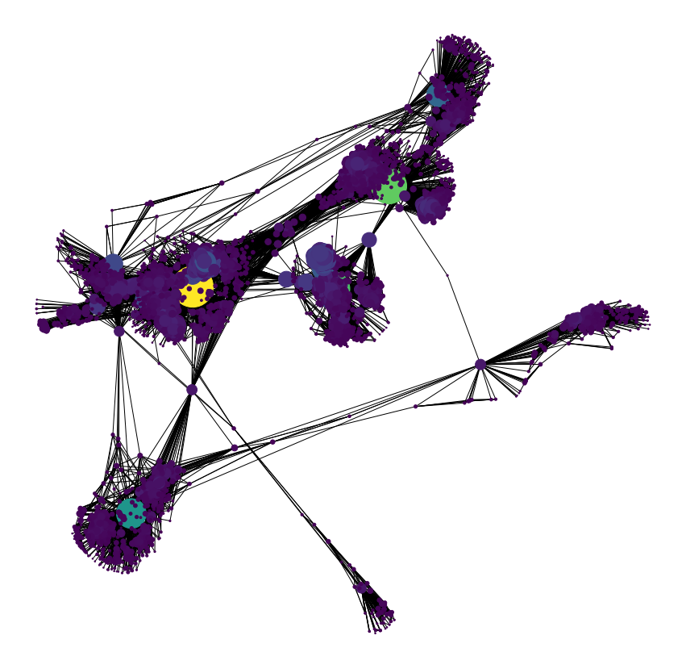

```python
pos = nx.spring_layout(G1)
degCent = nx.degree_centrality(G1)
node_color = [20000.0 * G1.degree(v) for v in G1]
node_size =  [v * 10000 for v in degCent.values()]
plt.figure(figsize=(15,15))
nx.draw_networkx(G1, pos=pos, with_labels=False,
                 node_color=node_color,
                 node_size=node_size )
plt.axis('off')

sorted(degCent, key=degCent.get, reverse=True)[:5]
```

```python
sorted(degCent, key=degCent.get, reverse=True)[:5]
```

```
[107, 1684, 1912, 3437, 0]
```

# III. Closeness Centrality

In a connected graph, closeness centrality of a node is a measure of centrality in a network, calculated as the reciprocal of the sum of the length of the shortest paths between the node and all other nodes in the graph. Thus, the more central a node is, the closer it is to all other nodes. The mathematical equation is : $C(x) = \frac{1}{\sum_{y}d(y,x)}$, where :  
$d(y,x)$ : the distance between vertices $x$ and $y$

```
[107, 58, 428, 563, 1684]
```

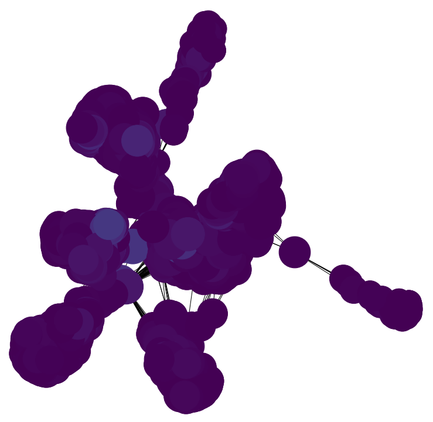

```python
pos = nx.spring_layout(G1)
cloCent = nx.closeness_centrality(G1)
node_color = [20000.0 * G1.degree(v) for v in G1]
node_size =  [v * 10000 for v in cloCent.values()]
plt.figure(figsize=(13,13))
nx.draw_networkx(G1, pos=pos, with_labels=False,
                 node_color=node_color,
                 node_size=node_size )
plt.axis('off')
sorted(cloCent, key=cloCent.get, reverse=True)[:5]
```

```python
max(x for x,y in nx.degree(G1))
```

```
4038
```

# IV. Shortest Path in the graph

```python
sources = [20,40,65,75]
targets = [650,802,920,1010]
for i in range(4):
    path = nx.shortest_path(G1,source=sources[i],target=targets[i])
    length = nx.shortest_path_length(G1,source=sources[i],target=targets[i],method='dijkstra')
    print("Shortest Path between Node ", str(sources[i])," ---> ", str(targets[i]), " is ",
          str(path), " ,Length = ", str(length))
```

```
Shortest Path between Node  20  --->  650  is  [20, 0, 34, 414, 650]  ,Length =  4
Shortest Path between Node  40  --->  802  is  [40, 0, 58, 1684, 860, 698, 686, 802]  ,Length =  7
Shortest Path between Node  65  --->  920  is  [65, 0, 107, 920]  ,Length =  3
Shortest Path between Node  75  --->  1010  is  [75, 0, 107, 1010]  ,Length =  3
```

# V. Determine all neighbors for a given node

```python
neigh = [1,20,40,65,75,90,1000,]
for i in range(len(neigh)):
    all_neighbors = list(nx.classes.function.all_neighbors(G1,neigh[i]))
    print("All neighbors for Node ", str(neigh[i])," ---> ", str(all_neighbors))
```

```
All neighbors for Node  1  --->  [0, 48, 53, 54, 73, 88, 92, 119, 126, 133, 194, 236, 280, 299, 315, 322, 346]
All neighbors for Node  20  --->  [0, 2, 14, 41, 44, 111, 115, 149, 162, 214, 226, 312, 326, 333, 343]
All neighbors for Node  40  --->  [0, 21, 25, 26, 29, 56, 67, 72, 77, 113, 132, 133, 141, 142, 158, 169, 172, 199, 200, 203, 212, 213, 224, 231, 232, 239, 257, 258, 265, 271, 272, 274, 277, 280, 298, 304, 307, 315, 317, 322, 325, 329, 332, 334]
All neighbors for Node  65  --->  [0, 7, 13, 25, 82, 118, 203, 252, 261, 297, 314, 339]
All neighbors for Node  75  --->  [0, 9, 56, 67, 85, 170, 188, 200, 258, 272, 274, 304, 322, 323]
All neighbors for Node  90  --->  [0, 179]
All neighbors for Node  1000  --->  [107, 924, 974, 985, 1010, 1127, 1134, 1228, 1304, 1474, 1640, 1667, 1703, 1725, 1759, 1840]
```

```python
list(nx.selfloop_edges(G1, keys=True, data=True))
```

```
[]
```

### Degree nodes count

```python
d = dict(G1.degree()).values()
Counter(d)
```

```
Counter({347: 1,
         17: 76,
         10: 95,
         13: 79,
         6: 98,
         20: 63,
         8: 111,
         57: 23,
         1: 75,
         31: 38,
         15: 106,
         9: 100,
         16: 82,
         65: 20,
         11: 81,
```

[output cut: 212 more lines]

# VI. Eigenvector Centrality

With Eigenvector Centrality relative scores are assigned to all nodes in the network based on the concept that connections to high-scoring nodes contribute more to the score of the node in question than equal connections to low-scoring nodes. A high eigenvector score means that a node is connected to many nodes who themselves have high scores.

```
(-0.5521199703216553,
 1.0739104747772217,
 -0.6862687677145004,
 0.8673598974943161)
```

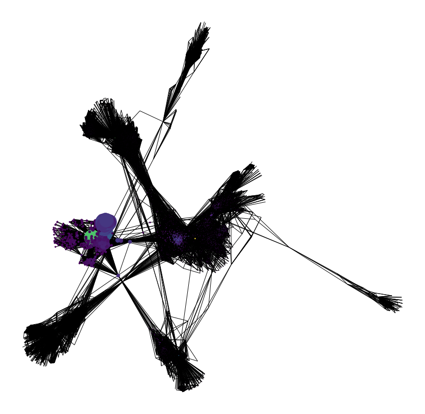

```python
#pos = nx.spring_layout(G1)
eigCent = nx.eigenvector_centrality(G1)
node_color = [20000.0 * G1.degree(v) for v in G1]
node_size =  [v * 10000 for v in eigCent.values()]
plt.figure(figsize=(15,15))
nx.draw_networkx(G1, pos=pos, with_labels=False,
                 node_color=node_color,
                 node_size=node_size )
plt.axis('off')
```

```python
sorted(eigCent, key=eigCent.get, reverse=True)[:5]
```

```
[1912, 2266, 2206, 2233, 2464]
```

### K-clique method

The K-lique method is so CPU/GPU consuming, so we decided to interrupt its running since it took more than 10 minutes.

```python
#list(nx.algorithms.community.k_clique_communities(G1,k=2))
```